# Background

# Data Preparation/Cleaning

To get started I downloaded essential libraries of Python.

```python
import numpy as np
import pandas as pd
import matplotlib.pyplot as plt
import seaborn as sns
from matplotlib.pyplot import figure
%matplotlib inline
```

```python
data = pd.read_csv('CTA_-_Ridership_-__L__Station_Entries_-_Daily_Totals_UPDATED.csv')
```

```python
data.head()
```

|  | station_id | stationname | date | daytype | rides |
| --- | --- | --- | --- | --- | --- |
| 0 | 40350 | UIC-Halsted | 01/01/2001 | U | 273 |
| 1 | 41130 | Halsted-Orange | 01/01/2001 | U | 306 |
| 2 | 40760 | Granville | 01/01/2001 | U | 1059 |
| 3 | 40070 | Jackson/Dearborn | 01/01/2001 | U | 649 |
| 4 | 40090 | Damen-Brown | 01/01/2001 | U | 411 |

```python
data.shape
```

```
(923384, 5)
```

Dataset has three object types and two integers.

```python
data.info()
```

```
<class 'pandas.core.frame.DataFrame'>
RangeIndex: 923384 entries, 0 to 923383
Data columns (total 5 columns):
station_id     923384 non-null int64
stationname    923384 non-null object
date           923384 non-null object
daytype        923384 non-null object
rides          923384 non-null int64
dtypes: int64(2), object(3)
memory usage: 35.2+ MB
```

```python
data.rename(columns={'stationname':'Station_Name','date':'Date','daytype':'Day_Type','rides':'Rides'},inplace=True)
data.head()
```

|  | station_id | Station_Name | Date | Day_Type | Rides |
| --- | --- | --- | --- | --- | --- |
| 0 | 40350 | UIC-Halsted | 01/01/2001 | U | 273 |
| 1 | 41130 | Halsted-Orange | 01/01/2001 | U | 306 |
| 2 | 40760 | Granville | 01/01/2001 | U | 1059 |
| 3 | 40070 | Jackson/Dearborn | 01/01/2001 | U | 649 |
| 4 | 40090 | Damen-Brown | 01/01/2001 | U | 411 |

Here I'm comparing Saturdays with Sundays and Holidays. A - Saturday, U - Sundays and Holidays.

```python
a_u = data.loc[data.Day_Type.isin(["A","U"]), ['Day_Type','Rides']].groupby('Day_Type').sum()
a_u
```

| Day_Type | Rides |
| --- | --- |
| A | 299231035 |
| U | 242730083 |

```python
from matplotlib.ticker import FuncFormatter
```

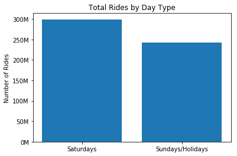

```python
ind = np.arange(len(a_u))
plt.bar(ind, height=a_u.Rides)
plt.xticks(ind, ["Saturdays", "Sundays/Holidays"])
plt.title("Total Rides by Day Type")
def millions(val, pos):
    return f'{val*1e-6:.0f}M'

formatter = FuncFormatter(millions)
plt.gca().yaxis.set_major_formatter(formatter)

plt.ylabel("Number of Rides")
```

Here we see that Saturday has a higher average ridership than Sundays and Holidays.

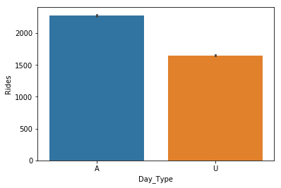

```python
for_sns = data.loc[data.Day_Type.isin(["U","A"]), ['Day_Type','Rides']]
sns.barplot(x='Day_Type',y='Rides',data=for_sns, order=["A", "U"])
```

To make further analysis more efficient, I converted the date column's object values to a non-null DateTime using a specific function, then derived years, months and weekdays by creating new variables for each.

```python
import datetime
data.Date = pd.to_datetime(data.Date)
data.head()
```

|  | station_id | Station_Name | Date | Day_Type | Rides |
| --- | --- | --- | --- | --- | --- |
| 0 | 40350 | UIC-Halsted | 2001-01-01 | U | 273 |
| 1 | 41130 | Halsted-Orange | 2001-01-01 | U | 306 |
| 2 | 40760 | Granville | 2001-01-01 | U | 1059 |
| 3 | 40070 | Jackson/Dearborn | 2001-01-01 | U | 649 |
| 4 | 40090 | Damen-Brown | 2001-01-01 | U | 411 |

```python
data['Year'] = data.Date.dt.year
data['Month'] = data.Date.dt.month
data['Weekday_Name'] = data.Date.dt.weekday_name
data.head()
```

|  | station_id | Station_Name | Date | Day_Type | Rides | Year | Month | Weekday_Name |
| --- | --- | --- | --- | --- | --- | --- | --- | --- |
| 0 | 40350 | UIC-Halsted | 2001-01-01 | U | 273 | 2001 | 1 | Monday |
| 1 | 41130 | Halsted-Orange | 2001-01-01 | U | 306 | 2001 | 1 | Monday |
| 2 | 40760 | Granville | 2001-01-01 | U | 1059 | 2001 | 1 | Monday |
| 3 | 40070 | Jackson/Dearborn | 2001-01-01 | U | 649 | 2001 | 1 | Monday |
| 4 | 40090 | Damen-Brown | 2001-01-01 | U | 411 | 2001 | 1 | Monday |

This data frame includes reports for 6481 days.

```python
data.Date.max()-data.Date.min()
```

```
Timedelta('6481 days 00:00:00')
```

## Data Visualization

```
(0, 200527857.8)
```

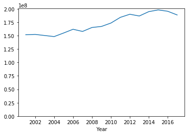

```python
grouped = data.groupby(['Year']).Rides.sum()
grouped.loc[grouped.index != 2018].plot(kind="line", y="Rides")
plt.ylim(bottom=0)
```

```python
by_year = data.loc[data.Year !=2018].groupby('Year').Rides.sum()
by_year = by_year.to_frame()
by_year = by_year.reset_index()
```

```python
by_year
```

|  | Year | Rides |
| --- | --- | --- |
| 0 | 2001 | 151739502 |
| 1 | 2002 | 152364552 |
| 2 | 2003 | 150319580 |
| 3 | 2004 | 148312412 |
| 4 | 2005 | 154987157 |
| 5 | 2006 | 161966231 |
| 6 | 2007 | 157903245 |
| 7 | 2008 | 165290763 |
| 8 | 2009 | 167215635 |
| 9 | 2010 | 173561960 |
| 10 | 2011 | 184188885 |
| 11 | 2012 | 189958315 |
| 12 | 2013 | 186706688 |
| 13 | 2014 | 194826889 |
| 14 | 2015 | 198041408 |
| 15 | 2016 | 195555726 |
| 16 | 2017 | 188665453 |

```
([0, 1, 2, 3, 4, 5, 6, 7, 8, 9, 10, 11, 12, 13, 14, 15, 16],
 <a list of 17 Text xticklabel objects>)
```

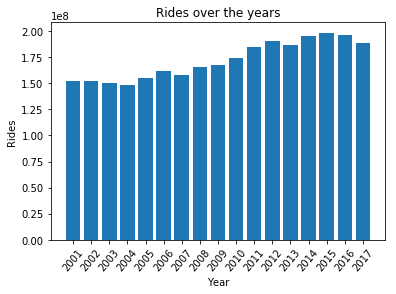

```python
fig, ax = plt.subplots()
index = ['2001','2002','2003','2004','2005','2006','2007','2008','2009','2010',
        '2011','2012','2013','2014','2015','2016','2017']
plt.bar(index, by_year['Rides'])
plt.title('Rides over the years')
plt.xlabel('Year')
plt.ylabel('Rides')
plt.xticks(rotation=50)
```

Here I am creating a multi-index data frame for a heatmap.

```python
multi = data.loc[data.Year!=2018].groupby(['Year','Month']).Rides.sum()
multi_plot = multi.unstack()
multi_plot
```

| Month Year | 1 | 2 | 3 | 4 | 5 | 6 | 7 | 8 | 9 | 10 | 11 | 12 |
| --- | --- | --- | --- | --- | --- | --- | --- | --- | --- | --- | --- | --- |
| 2001 | 12286897 | 11415793 | 12914296 | 12287737 | 13148263 | 13016951 | 13382993 | 13374592 | 12314751 | 13916090 | 12476056 | 11205083 |
| 2002 | 12309991 | 11506712 | 12183410 | 12815884 | 12973404 | 12714364 | 13392822 | 13036551 | 13078121 | 14374766 | 12434841 | 11543686 |
| 2003 | 11860130 | 11203581 | 12341355 | 12391027 | 12602473 | 12715662 | 13376266 | 12687510 | 13328526 | 14448488 | 11813039 | 11551523 |
| 2004 | 11309196 | 11347503 | 12773186 | 12333972 | 12067329 | 12968602 | 12849068 | 12529356 | 13107556 | 13384825 | 12271717 | 11370102 |
| 2005 | 11581403 | 11401625 | 12659665 | 12755659 | 12964006 | 13498294 | 13139642 | 13538824 | 14194677 | 14336020 | 12938006 | 11979336 |
| 2006 | 12407347 | 11889136 | 13710273 | 12951806 | 14089195 | 14001407 | 14148715 | 14444081 | 14264352 | 14747955 | 13317975 | 11993989 |
| 2007 | 12617830 | 11366892 | 13445416 | 12574531 | 13647689 | 13698349 | 14046147 | 14035867 | 13603498 | 14710126 | 12796204 | 11360696 |
| 2008 | 12329732 | 12410563 | 12916861 | 13837585 | 13944972 | 14077655 | 14898685 | 14702332 | 14780937 | 15822528 | 13156204 | 12412709 |
| 2009 | 12670605 | 12495760 | 13906626 | 13884272 | 13766591 | 14391134 | 15133049 | 14337678 | 15039598 | 15404020 | 13580544 | 12605758 |
| 2010 | 12713539 | 12794456 | 14553926 | 14590334 | 14380178 | 15119802 | 15169200 | 15321024 | 15671310 | 15909767 | 14441053 | 12897371 |
| 2011 | 13481258 | 13081983 | 15432089 | 14812301 | 15151493 | 15980399 | 16825884 | 17036083 | 16220005 | 16695016 | 15339673 | 14132701 |
| 2012 | 14665493 | 14770667 | 16276278 | 15465258 | 16155559 | 16288673 | 15773338 | 16883876 | 16287906 | 17825589 | 15716325 | 13849353 |
| 2013 | 14757704 | 14033842 | 15251953 | 15885919 | 15715412 | 15256300 | 16037793 | 16234436 | 16001038 | 17598968 | 15654406 | 14278917 |
| 2014 | 14268127 | 14587621 | 16421749 | 16599115 | 16649634 | 16487634 | 17042911 | 16734994 | 17306655 | 18411645 | 15337239 | 14979565 |
| 2015 | 14698498 | 14097691 | 16449070 | 16404520 | 16492679 | 17255694 | 17977486 | 17049933 | 17772902 | 18632339 | 15984523 | 15226073 |
| 2016 | 14836599 | 15212277 | 16677633 | 16141007 | 16597555 | 17085925 | 16813640 | 16886476 | 17097002 | 17885645 | 16322767 | 13999200 |
| 2017 | 14626737 | 14142406 | 16073109 | 15169117 | 16298485 | 16737259 | 15917931 | 16967756 | 16572350 | 17336213 | 15338822 | 13485268 |

```
(0, 200527857.8)
```

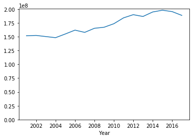

```python
multi_plot.sum(axis=1).plot()
plt.ylim(bottom=0)
```

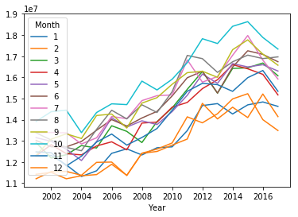

```python
multi_plot.loc[:, :].plot()
```

One might expect to see a significant decrease in the summertime because people are more active in the warm weather. They can walk, bike or skate, etc., to get to the desired spot, but from the plot below, we observe the most significant decrease happens during the winter time, especially January.

Why do we take a train? To get to the work, school, or seek entertainment. Admittedly, if the weather is unpleasant, and I can afford to use a Lyft or Uber service, I would instead do that than walk to the train station.

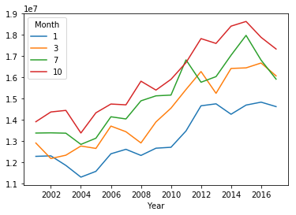

```python
multi_plot.loc[:, [1, 3, 7, 10]].plot()
```

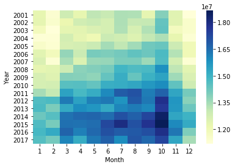

```python
sns.heatmap(multi_plot,cmap="YlGnBu")
```

##### Ten busiest stations.

It's not surprising that the downtown stations are the busiest given the number of people that work and seek entertainment near those stations. A notable exception is O'Hare, which is understandable given that the CTA provides a convenient way to access one of the busiest airports in the world.

```python
by_station = data[['Station_Name','Rides']]
by_station = by_station.groupby('Station_Name').sum()
by_station = by_station.sort_values(by='Rides', ascending=False)
by_station.head(10)
```

| Station_Name | Rides |
| --- | --- |
| Clark/Lake | 90440007 |
| Lake/State | 89436950 |
| Chicago/State | 84027079 |
| 95th/Dan Ryan | 68656216 |
| Belmont-North Main | 67860822 |
| Fullerton | 66562305 |
| Grand/State | 62054451 |
| O'Hare Airport | 59339717 |
| Jackson/State | 57532433 |
| Roosevelt | 55203280 |

##### Ten least busy stations.

The low ridership at the Washington/Wabash, which is the downtown area, is explainable. It didn't open until August 31, 2017.

```python
by_station.tail(10)
```

| Station_Name | Rides |
| --- | --- |
| Foster | 4332919 |
| South Boulevard | 4269501 |
| Noyes | 4015029 |
| Dempster-Skokie | 3959918 |
| King Drive | 3645039 |
| Washington/Wabash | 3383379 |
| Kostner | 2184938 |
| Cermak-McCormick Place | 1715943 |
| Oakton-Skokie | 1695782 |
| Homan | 27 |

#### My next interest is to find out the cause of the decrease for the CTA ridership last couple of years. I found an 'L' stops dataset from the same data portal that provided me with location and basic service availability information for each place on the CTA system where a train stops, along with formal station names and stops descriptions. I also think that decrease could occur on only particular lines. Let's investigate it further with the new dataset.

```python
stops_data = pd.read_csv("CTA_-_System_Information_-_List_of__L__Stops.csv")
```

```python
stops_data.shape
```

```
(300, 17)
```

```python
stops_data.info()
```

```
<class 'pandas.core.frame.DataFrame'>
RangeIndex: 300 entries, 0 to 299
Data columns (total 17 columns):
STOP_ID                     300 non-null int64
DIRECTION_ID                300 non-null object
STOP_NAME                   300 non-null object
STATION_NAME                300 non-null object
STATION_DESCRIPTIVE_NAME    300 non-null object
MAP_ID                      300 non-null int64
ADA                         300 non-null bool
RED                         300 non-null bool
BLUE                        300 non-null bool
G                           300 non-null bool
BRN                         300 non-null bool
P                           300 non-null bool
Pexp                        300 non-null bool
Y                           300 non-null bool
Pnk                         300 non-null bool
O                           300 non-null bool
Location                    300 non-null object
dtypes: bool(10), int64(2), object(5)
memory usage: 19.4+ KB
```

```python
stops_data.head()
```

|  | STOP_ID | DIRECTION_ID | STOP_NAME | STATION_NAME | STATION_DESCRIPTIVE_NAME | MAP_ID | ADA | RED | BLUE | G | BRN | P | Pexp | Y | Pnk | O | Location |
| --- | --- | --- | --- | --- | --- | --- | --- | --- | --- | --- | --- | --- | --- | --- | --- | --- | --- |
| 0 | 30161 | E | 18th (Loop-bound) | 18th | 18th (Pink Line) | 40830 | True | False | False | False | False | False | False | False | True | False | (41.857908, -87.669147) |
| 1 | 30162 | W | 18th (54th/Cermak-bound) | 18th | 18th (Pink Line) | 40830 | True | False | False | False | False | False | False | False | True | False | (41.857908, -87.669147) |
| 2 | 30022 | N | 35th/Archer (Loop-bound) | 35th/Archer | 35th/Archer (Orange Line) | 40120 | True | False | False | False | False | False | False | False | False | True | (41.829353, -87.680622) |
| 3 | 30023 | S | 35th/Archer (Midway-bound) | 35th/Archer | 35th/Archer (Orange Line) | 40120 | True | False | False | False | False | False | False | False | False | True | (41.829353, -87.680622) |
| 4 | 30213 | N | 35-Bronzeville-IIT (Harlem-bound) | 35th-Bronzeville-IIT | 35th-Bronzeville-IIT (Green Line) | 41120 | True | False | False | True | False | False | False | False | False | False | (41.831677, -87.625826) |

```python
stops_data.columns
```

```
Index(['STOP_ID', 'DIRECTION_ID', 'STOP_NAME', 'STATION_NAME',
       'STATION_DESCRIPTIVE_NAME', 'MAP_ID', 'ADA', 'RED', 'BLUE', 'G', 'BRN',
       'P', 'Pexp', 'Y', 'Pnk', 'O', 'Location'],
      dtype='object')
```

For the better readability I converted column names. I decided to work only with line's columns to find out certain lines where decrease has occured.

```python
stops_data.rename({"G": "GREEN", "BRN": "BROWN", "P": "PURPLE", "Y": "YELLOW", "Pnk": "PINK",
                   "O": "ORANGE"}, axis="columns", inplace=True)
```

```python
stops_data.head()
```

|  | STOP_ID | DIRECTION_ID | STOP_NAME | STATION_NAME | STATION_DESCRIPTIVE_NAME | MAP_ID | ADA | RED | BLUE | GREEN | BROWN | PURPLE | Pexp | YELLOW | PINK | ORANGE | Location |
| --- | --- | --- | --- | --- | --- | --- | --- | --- | --- | --- | --- | --- | --- | --- | --- | --- | --- |
| 0 | 30161 | E | 18th (Loop-bound) | 18th | 18th (Pink Line) | 40830 | True | False | False | False | False | False | False | False | True | False | (41.857908, -87.669147) |
| 1 | 30162 | W | 18th (54th/Cermak-bound) | 18th | 18th (Pink Line) | 40830 | True | False | False | False | False | False | False | False | True | False | (41.857908, -87.669147) |
| 2 | 30022 | N | 35th/Archer (Loop-bound) | 35th/Archer | 35th/Archer (Orange Line) | 40120 | True | False | False | False | False | False | False | False | False | True | (41.829353, -87.680622) |
| 3 | 30023 | S | 35th/Archer (Midway-bound) | 35th/Archer | 35th/Archer (Orange Line) | 40120 | True | False | False | False | False | False | False | False | False | True | (41.829353, -87.680622) |
| 4 | 30213 | N | 35-Bronzeville-IIT (Harlem-bound) | 35th-Bronzeville-IIT | 35th-Bronzeville-IIT (Green Line) | 41120 | True | False | False | True | False | False | False | False | False | False | (41.831677, -87.625826) |

```python
colors = ['RED', 'BLUE', 'GREEN','BROWN', 'PURPLE', 'YELLOW', 'PINK', 'ORANGE']
stops = stops_data.groupby('MAP_ID').sum()[colors]
```

```python
stops = stops > 0
```

```python
stops['line_count'] = stops.apply(lambda x: sum(x), axis=1)
```

```python
stops.head()
```

| MAP_ID | RED | BLUE | GREEN | BROWN | PURPLE | YELLOW | PINK | ORANGE | line_count |
| --- | --- | --- | --- | --- | --- | --- | --- | --- | --- |
| 40010 | False | True | False | False | False | False | False | False | 1 |
| 40020 | False | False | True | False | False | False | False | False | 1 |
| 40030 | False | False | True | False | False | False | False | False | 1 |
| 40040 | False | False | False | True | False | False | True | True | 3 |
| 40050 | False | False | False | False | True | False | False | False | 1 |

Here I'm merging stops dataset with the previous one.

```python
merged = data.merge(stops, how="inner", left_on="station_id", right_index=True)
```

```python
merged.shape
```

```
(907700, 17)
```

Here I divided Rides by line count so we can get the number of rides for every single line.

```python
merged["rides_split"] = merged['Rides'] / merged["line_count"]
```

```python
merged.head()
```

|  | station_id | Station_Name | Date | Day_Type | Rides | Year | Month | Weekday_Name | RED | BLUE | GREEN | BROWN | PURPLE | YELLOW | PINK | ORANGE | line_count | rides_split |
| --- | --- | --- | --- | --- | --- | --- | --- | --- | --- | --- | --- | --- | --- | --- | --- | --- | --- | --- |
| 0 | 40350 | UIC-Halsted | 2001-01-01 | U | 273 | 2001 | 1 | Monday | False | True | False | False | False | False | False | False | 1 | 273.0 |
| 281 | 40350 | UIC-Halsted | 2001-01-02 | W | 1775 | 2001 | 1 | Tuesday | False | True | False | False | False | False | False | False | 1 | 1775.0 |
| 380 | 40350 | UIC-Halsted | 2001-01-03 | W | 1945 | 2001 | 1 | Wednesday | False | True | False | False | False | False | False | False | 1 | 1945.0 |
| 520 | 40350 | UIC-Halsted | 2001-01-04 | W | 2049 | 2001 | 1 | Thursday | False | True | False | False | False | False | False | False | 1 | 2049.0 |
| 576 | 40350 | UIC-Halsted | 2001-01-05 | W | 2145 | 2001 | 1 | Friday | False | True | False | False | False | False | False | False | 1 | 2145.0 |

```python
tidy = merged.melt(id_vars=["rides_split", "Year"], value_vars=colors)
```

```python
agg = tidy.loc[tidy.value == True].groupby(["variable", "Year"]).sum()[['rides_split']].reset_index().pivot(index="Year", columns="variable", values="rides_split")
agg
```

| variable Year | BLUE | BROWN | GREEN | ORANGE | PINK | PURPLE | RED | YELLOW |
| --- | --- | --- | --- | --- | --- | --- | --- | --- |
| 2001 | 33865407.6 | 2.072044e+07 | 1.168378e+07 | 1.184586e+07 | 6.799123e+06 | 3.721133e+06 | 5.664414e+07 | 1.340514e+06 |
| 2002 | 34198497.0 | 2.061362e+07 | 1.164657e+07 | 1.186950e+07 | 6.487685e+06 | 3.691313e+06 | 5.754893e+07 | 1.290552e+06 |
| 2003 | 34254024.6 | 2.049722e+07 | 1.142480e+07 | 1.179073e+07 | 6.081805e+06 | 3.725025e+06 | 5.624450e+07 | 1.248086e+06 |
| 2004 | 34722251.0 | 1.999848e+07 | 1.117730e+07 | 1.168161e+07 | 6.227071e+06 | 3.640151e+06 | 5.418368e+07 | 1.222303e+06 |
| 2005 | 36420877.8 | 2.073970e+07 | 1.197740e+07 | 1.222783e+07 | 7.372824e+06 | 3.675578e+06 | 5.515340e+07 | 1.264254e+06 |
| 2006 | 37143123.0 | 2.137513e+07 | 1.316785e+07 | 1.300450e+07 | 8.299912e+06 | 3.683375e+06 | 5.842055e+07 | 1.267907e+06 |
| 2007 | 35154547.6 | 2.050687e+07 | 1.379676e+07 | 1.337732e+07 | 9.051837e+06 | 3.608735e+06 | 5.733811e+07 | 1.222013e+06 |
| 2008 | 37469468.2 | 2.150122e+07 | 1.442288e+07 | 1.388000e+07 | 9.929510e+06 | 3.857722e+06 | 5.890128e+07 | 1.351210e+06 |
| 2009 | 35841714.0 | 2.323442e+07 | 1.397110e+07 | 1.334631e+07 | 9.732629e+06 | 3.825156e+06 | 6.206706e+07 | 1.381305e+06 |
| 2010 | 38389348.6 | 2.449536e+07 | 1.415624e+07 | 1.325109e+07 | 9.785793e+06 | 3.820456e+06 | 6.431838e+07 | 1.445807e+06 |
| 2011 | 41998771.2 | 2.644686e+07 | 1.471940e+07 | 1.403480e+07 | 1.042249e+07 | 3.964854e+06 | 6.697212e+07 | 1.488367e+06 |
| 2012 | 44258122.0 | 2.762370e+07 | 1.511313e+07 | 1.466414e+07 | 1.094478e+07 | 3.982528e+06 | 6.737357e+07 | 1.649713e+06 |
| 2013 | 45488965.8 | 2.783215e+07 | 1.854055e+07 | 1.472896e+07 | 1.104796e+07 | 3.911393e+06 | 5.916106e+07 | 1.669586e+06 |
| 2014 | 46062158.0 | 2.813722e+07 | 1.550121e+07 | 1.478298e+07 | 1.134472e+07 | 3.992435e+06 | 6.896777e+07 | 1.667722e+06 |
| 2015 | 47954372.8 | 2.786614e+07 | 1.600629e+07 | 1.517913e+07 | 1.188922e+07 | 4.058505e+06 | 7.050709e+07 | 1.209839e+06 |
| 2016 | 47410395.2 | 2.844400e+07 | 1.509343e+07 | 1.515046e+07 | 1.155099e+07 | 3.910705e+06 | 6.946917e+07 | 1.519796e+06 |
| 2017 | 46313891.6 | 2.806281e+07 | 1.495477e+07 | 1.508449e+07 | 1.153090e+07 | 3.800883e+06 | 6.540234e+07 | 1.527440e+06 |
| 2018 | 34203006.4 | 2.138958e+07 | 1.157787e+07 | 1.141146e+07 | 9.054718e+06 | 2.803359e+06 | 4.760219e+07 | 1.111365e+06 |

Here we see an abrupt decrease in the yellow line in 2015. If you google, you'll run into an article that says; there was a five-month shutdown in the CTA Yellow Line this year.

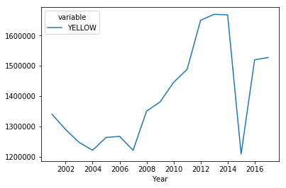

```python
agg.loc[agg.index != 2018, ["YELLOW"]].plot(kind="line", legend="right")
```

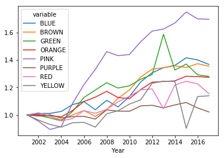

```python
(agg / agg.loc[2001]).loc[agg.index != 2018].plot(kind="line", legend="right")
```

# Conclusion

From the analysis above, we were able to extract insightful information like a decrease or increase of the ridership for particular lines. What could be the primary influence on the decline of ridership on some lines? Can you consider that it might be a matter of safety, that people try to avoid taking trains from certain lines or it's just a matter of location?! My further goal is to try to answer this question using "Crime data" from the Chicago data portal.

```python
df = pd.read_csv('Crimes_-_2001_to_present.csv')
```

```python
df.head()
```

|  | ID | Case Number | Date | Block | IUCR | Primary Type | Description | Location Description | Arrest | Domestic | ... | Ward | Community Area | FBI Code | X Coordinate | Y Coordinate | Year | Updated On | Latitude | Longitude | Location |
| --- | --- | --- | --- | --- | --- | --- | --- | --- | --- | --- | --- | --- | --- | --- | --- | --- | --- | --- | --- | --- | --- |
| 0 | 10000092 | HY189866 | 03/18/2015 07:44:00 PM | 047XX W OHIO ST | 041A | BATTERY | AGGRAVATED: HANDGUN | STREET | False | False | ... | 28.0 | 25.0 | 04B | 1144606.0 | 1903566.0 | 2015 | 02/10/2018 03:50:01 PM | 41.891399 | -87.744385 | (41.891398861, -87.744384567) |
| 1 | 10000094 | HY190059 | 03/18/2015 11:00:00 PM | 066XX S MARSHFIELD AVE | 4625 | OTHER OFFENSE | PAROLE VIOLATION | STREET | True | False | ... | 15.0 | 67.0 | 26 | 1166468.0 | 1860715.0 | 2015 | 02/10/2018 03:50:01 PM | 41.773372 | -87.665319 | (41.773371528, -87.665319468) |
| 2 | 10000095 | HY190052 | 03/18/2015 10:45:00 PM | 044XX S LAKE PARK AVE | 0486 | BATTERY | DOMESTIC BATTERY SIMPLE | APARTMENT | False | True | ... | 4.0 | 39.0 | 08B | 1185075.0 | 1875622.0 | 2015 | 02/10/2018 03:50:01 PM | 41.813861 | -87.596643 | (41.81386068, -87.596642837) |
| 3 | 10000096 | HY190054 | 03/18/2015 10:30:00 PM | 051XX S MICHIGAN AVE | 0460 | BATTERY | SIMPLE | APARTMENT | False | False | ... | 3.0 | 40.0 | 08B | 1178033.0 | 1870804.0 | 2015 | 02/10/2018 03:50:01 PM | 41.800802 | -87.622619 | (41.800802415, -87.622619343) |
| 4 | 10000097 | HY189976 | 03/18/2015 09:00:00 PM | 047XX W ADAMS ST | 031A | ROBBERY | ARMED: HANDGUN | SIDEWALK | False | False | ... | 28.0 | 25.0 | 03 | 1144920.0 | 1898709.0 | 2015 | 02/10/2018 03:50:01 PM | 41.878065 | -87.743354 | (41.878064761, -87.743354013) |

5 rows × 22 columns

```python
df.rename(columns={'Description':'description'}, inplace=True)
```

```python
df.rename(columns={'Location Description':'location_description'}, inplace=True)
```

```python
df.info()
```

```
<class 'pandas.core.frame.DataFrame'>
RangeIndex: 6800825 entries, 0 to 6800824
Data columns (total 22 columns):
ID                      int64
Case Number             object
Date                    object
Block                   object
IUCR                    object
Primary Type            object
description             object
location_description    object
Arrest                  bool
Domestic                bool
Beat                    int64
District                float64
Ward                    float64
Community Area          float64
FBI Code                object
X Coordinate            float64
Y Coordinate            float64
Year                    int64
Updated On              object
Latitude                float64
Longitude               float64
Location                object
dtypes: bool(2), float64(7), int64(3), object(10)
memory usage: 1.0+ GB
```